# Risk Factor Analysis

## Outcome Variable

**Outcome Variable:** wast_rec90d

## Predictor Variables

**Intervention Variable:** impsan

**Adjustment Set:**

- arm
- sex
- W_mage
- meducyrs
- feducyrs
- hhwealth_quart
- hfoodsec
- W_mhtcm
- W_nrooms
- W_nchldlt5
- W_parity
- impfloor
- safeh20
- delta_W_mage
- delta_meducyrs
- delta_feducyrs
- delta_hhwealth_quart
- delta_hfoodsec
- delta_W_mhtcm
- delta_W_nrooms
- delta_W_nchldlt5
- delta_W_parity
- delta_impfloor
- delta_safeh20

## Stratifying Variables

The analysis was stratified on these variable(s):

- agecat
- studyid
- country

## Data Summary

| agecat | studyid | country | impsan | wast_rec90d | n_cell | n |
| --- | --- | --- | --- | --- | --- | --- |
| 0-24 months | ki0047075b-MAL-ED | BANGLADESH | 0 | 0 | 10 | 121 |
| 0-24 months | ki0047075b-MAL-ED | BANGLADESH | 0 | 1 | 11 | 121 |
| 0-24 months | ki0047075b-MAL-ED | BANGLADESH | 1 | 0 | 34 | 121 |
| 0-24 months | ki0047075b-MAL-ED | BANGLADESH | 1 | 1 | 66 | 121 |
| 0-24 months | ki0047075b-MAL-ED | BRAZIL | 0 | 0 | 0 | 23 |
| 0-24 months | ki0047075b-MAL-ED | BRAZIL | 0 | 1 | 1 | 23 |
| 0-24 months | ki0047075b-MAL-ED | BRAZIL | 1 | 0 | 6 | 23 |
| 0-24 months | ki0047075b-MAL-ED | BRAZIL | 1 | 1 | 16 | 23 |
| 0-24 months | ki0047075b-MAL-ED | INDIA | 0 | 0 | 40 | 170 |
| 0-24 months | ki0047075b-MAL-ED | INDIA | 0 | 1 | 64 | 170 |
| 0-24 months | ki0047075b-MAL-ED | INDIA | 1 | 0 | 25 | 170 |
| 0-24 months | ki0047075b-MAL-ED | INDIA | 1 | 1 | 41 | 170 |
| 0-24 months | ki0047075b-MAL-ED | NEPAL | 0 | 0 | 0 | 92 |
| 0-24 months | ki0047075b-MAL-ED | NEPAL | 0 | 1 | 0 | 92 |
| 0-24 months | ki0047075b-MAL-ED | NEPAL | 1 | 0 | 19 | 92 |
| 0-24 months | ki0047075b-MAL-ED | NEPAL | 1 | 1 | 73 | 92 |
| 0-24 months | ki0047075b-MAL-ED | PERU | 0 | 0 | 3 | 32 |
| 0-24 months | ki0047075b-MAL-ED | PERU | 0 | 1 | 20 | 32 |
| 0-24 months | ki0047075b-MAL-ED | PERU | 1 | 0 | 3 | 32 |
| 0-24 months | ki0047075b-MAL-ED | PERU | 1 | 1 | 6 | 32 |
| 0-24 months | ki0047075b-MAL-ED | SOUTH AFRICA | 0 | 0 | 11 | 76 |
| 0-24 months | ki0047075b-MAL-ED | SOUTH AFRICA | 0 | 1 | 63 | 76 |
| 0-24 months | ki0047075b-MAL-ED | SOUTH AFRICA | 1 | 0 | 1 | 76 |
| 0-24 months | ki0047075b-MAL-ED | SOUTH AFRICA | 1 | 1 | 1 | 76 |
| 0-24 months | ki0047075b-MAL-ED | TANZANIA, UNITED REPUBLIC OF | 0 | 0 | 8 | 44 |
| 0-24 months | ki0047075b-MAL-ED | TANZANIA, UNITED REPUBLIC OF | 0 | 1 | 36 | 44 |
| 0-24 months | ki0047075b-MAL-ED | TANZANIA, UNITED REPUBLIC OF | 1 | 0 | 0 | 44 |
| 0-24 months | ki0047075b-MAL-ED | TANZANIA, UNITED REPUBLIC OF | 1 | 1 | 0 | 44 |
| 0-24 months | ki1017093-NIH-Birth | BANGLADESH | 0 | 0 | 136 | 421 |
| 0-24 months | ki1017093-NIH-Birth | BANGLADESH | 0 | 1 | 138 | 421 |

[output cut: 174 more lines]

The following strata were considered:

- agecat: 0-24 months, studyid: ki0047075b-MAL-ED, country: BANGLADESH
- agecat: 0-24 months, studyid: ki0047075b-MAL-ED, country: BRAZIL
- agecat: 0-24 months, studyid: ki0047075b-MAL-ED, country: INDIA
- agecat: 0-24 months, studyid: ki0047075b-MAL-ED, country: NEPAL
- agecat: 0-24 months, studyid: ki0047075b-MAL-ED, country: PERU
- agecat: 0-24 months, studyid: ki0047075b-MAL-ED, country: SOUTH AFRICA
- agecat: 0-24 months, studyid: ki0047075b-MAL-ED, country: TANZANIA, UNITED REPUBLIC OF
- agecat: 0-24 months, studyid: ki1017093-NIH-Birth, country: BANGLADESH
- agecat: 0-24 months, studyid: ki1017093b-PROVIDE, country: BANGLADESH
- agecat: 0-24 months, studyid: ki1017093c-NIH-Crypto, country: BANGLADESH
- agecat: 0-24 months, studyid: ki1114097-CONTENT, country: PERU
- agecat: 0-24 months, studyid: ki1135781-COHORTS, country: GUATEMALA
- agecat: 0-24 months, studyid: ki1135781-COHORTS, country: INDIA
- agecat: 0-24 months, studyid: ki1135781-COHORTS, country: PHILIPPINES
- agecat: 0-24 months, studyid: ki1148112-LCNI-5, country: MALAWI
- agecat: 0-24 months, studyid: kiGH5241-JiVitA-3, country: BANGLADESH
- agecat: 0-24 months, studyid: kiGH5241-JiVitA-4, country: BANGLADESH
- agecat: 0-6 months, studyid: ki0047075b-MAL-ED, country: BANGLADESH
- agecat: 0-6 months, studyid: ki0047075b-MAL-ED, country: BRAZIL
- agecat: 0-6 months, studyid: ki0047075b-MAL-ED, country: INDIA
- agecat: 0-6 months, studyid: ki0047075b-MAL-ED, country: NEPAL
- agecat: 0-6 months, studyid: ki0047075b-MAL-ED, country: PERU
- agecat: 0-6 months, studyid: ki0047075b-MAL-ED, country: SOUTH AFRICA
- agecat: 0-6 months, studyid: ki0047075b-MAL-ED, country: TANZANIA, UNITED REPUBLIC OF
- agecat: 0-6 months, studyid: ki1017093-NIH-Birth, country: BANGLADESH
- agecat: 0-6 months, studyid: ki1017093b-PROVIDE, country: BANGLADESH
- agecat: 0-6 months, studyid: ki1017093c-NIH-Crypto, country: BANGLADESH
- agecat: 0-6 months, studyid: ki1114097-CONTENT, country: PERU
- agecat: 0-6 months, studyid: ki1135781-COHORTS, country: GUATEMALA
- agecat: 0-6 months, studyid: ki1135781-COHORTS, country: INDIA
- agecat: 0-6 months, studyid: ki1135781-COHORTS, country: PHILIPPINES
- agecat: 0-6 months, studyid: ki1148112-LCNI-5, country: MALAWI
- agecat: 0-6 months, studyid: kiGH5241-JiVitA-3, country: BANGLADESH
- agecat: 0-6 months, studyid: kiGH5241-JiVitA-4, country: BANGLADESH
- agecat: 6-24 months, studyid: ki0047075b-MAL-ED, country: BANGLADESH
- agecat: 6-24 months, studyid: ki0047075b-MAL-ED, country: BRAZIL
- agecat: 6-24 months, studyid: ki0047075b-MAL-ED, country: INDIA
- agecat: 6-24 months, studyid: ki0047075b-MAL-ED, country: NEPAL
- agecat: 6-24 months, studyid: ki0047075b-MAL-ED, country: PERU
- agecat: 6-24 months, studyid: ki0047075b-MAL-ED, country: SOUTH AFRICA
- agecat: 6-24 months, studyid: ki0047075b-MAL-ED, country: TANZANIA, UNITED REPUBLIC OF
- agecat: 6-24 months, studyid: ki1017093-NIH-Birth, country: BANGLADESH
- agecat: 6-24 months, studyid: ki1017093b-PROVIDE, country: BANGLADESH
- agecat: 6-24 months, studyid: ki1017093c-NIH-Crypto, country: BANGLADESH
- agecat: 6-24 months, studyid: ki1114097-CONTENT, country: PERU
- agecat: 6-24 months, studyid: ki1135781-COHORTS, country: GUATEMALA
- agecat: 6-24 months, studyid: ki1135781-COHORTS, country: INDIA
- agecat: 6-24 months, studyid: ki1135781-COHORTS, country: PHILIPPINES
- agecat: 6-24 months, studyid: ki1148112-LCNI-5, country: MALAWI
- agecat: 6-24 months, studyid: kiGH5241-JiVitA-3, country: BANGLADESH
- agecat: 6-24 months, studyid: kiGH5241-JiVitA-4, country: BANGLADESH

### Dropped Strata

Some strata were dropped due to rare outcomes:

- agecat: 0-24 months, studyid: ki0047075b-MAL-ED, country: BRAZIL
- agecat: 0-24 months, studyid: ki0047075b-MAL-ED, country: NEPAL
- agecat: 0-24 months, studyid: ki0047075b-MAL-ED, country: PERU
- agecat: 0-24 months, studyid: ki0047075b-MAL-ED, country: SOUTH AFRICA
- agecat: 0-24 months, studyid: ki0047075b-MAL-ED, country: TANZANIA, UNITED REPUBLIC OF
- agecat: 0-24 months, studyid: ki1114097-CONTENT, country: PERU
- agecat: 0-24 months, studyid: ki1148112-LCNI-5, country: MALAWI
- agecat: 0-6 months, studyid: ki0047075b-MAL-ED, country: BANGLADESH
- agecat: 0-6 months, studyid: ki0047075b-MAL-ED, country: BRAZIL
- agecat: 0-6 months, studyid: ki0047075b-MAL-ED, country: NEPAL
- agecat: 0-6 months, studyid: ki0047075b-MAL-ED, country: PERU
- agecat: 0-6 months, studyid: ki0047075b-MAL-ED, country: SOUTH AFRICA
- agecat: 0-6 months, studyid: ki0047075b-MAL-ED, country: TANZANIA, UNITED REPUBLIC OF
- agecat: 0-6 months, studyid: ki1017093b-PROVIDE, country: BANGLADESH
- agecat: 0-6 months, studyid: ki1017093c-NIH-Crypto, country: BANGLADESH
- agecat: 0-6 months, studyid: ki1114097-CONTENT, country: PERU
- agecat: 0-6 months, studyid: ki1135781-COHORTS, country: GUATEMALA
- agecat: 0-6 months, studyid: ki1148112-LCNI-5, country: MALAWI
- agecat: 6-24 months, studyid: ki0047075b-MAL-ED, country: BANGLADESH
- agecat: 6-24 months, studyid: ki0047075b-MAL-ED, country: BRAZIL
- agecat: 6-24 months, studyid: ki0047075b-MAL-ED, country: NEPAL
- agecat: 6-24 months, studyid: ki0047075b-MAL-ED, country: PERU
- agecat: 6-24 months, studyid: ki0047075b-MAL-ED, country: SOUTH AFRICA
- agecat: 6-24 months, studyid: ki0047075b-MAL-ED, country: TANZANIA, UNITED REPUBLIC OF
- agecat: 6-24 months, studyid: ki1017093b-PROVIDE, country: BANGLADESH
- agecat: 6-24 months, studyid: ki1017093c-NIH-Crypto, country: BANGLADESH
- agecat: 6-24 months, studyid: ki1114097-CONTENT, country: PERU
- agecat: 6-24 months, studyid: ki1135781-COHORTS, country: GUATEMALA
- agecat: 6-24 months, studyid: ki1135781-COHORTS, country: INDIA
- agecat: 6-24 months, studyid: ki1148112-LCNI-5, country: MALAWI
- agecat: 6-24 months, studyid: kiGH5241-JiVitA-3, country: BANGLADESH

## Methods Detail

We’re interested in the causal parameters $E[Y_a]$ for all values of $a \in \mathcal{A}$. These parameters represent the mean outcome if, possibly contrary to fact, we intervened to set all units to have $A=a$. Under the randomization and positivity assumptions, these are identified by the statistical parameters $\psi_a=E_W[E_{Y|A,W}(Y|A=a,W)]$. In addition, we’re interested in the mean of $Y$, $E[Y]$ under no intervention (the observed mean). We will estimate these parameters by using SuperLearner to fit the relevant likelihood factors – $E_{Y|A,W}(Y|A=a,W)$ and $p(A=a|W)$, and then updating our likelihood fit using a joint TMLE.

For unadjusted analyses ($W=\{\}$), initial likelihoods were estimated using Lrnr_glm to estimate the simple $E(Y|A)$ and Lrnr_mean to estimate $p(A)$. For adjusted analyses, a small library containing Lrnr_glmnet, Lrnr_xgboost, and Lrnr_mean was used.

Having estimated these parameters, we will then use the delta method to estimate relative risks and attributable risks relative to a prespecified baseline level of $A$.

# Results Detail

## Results Plots

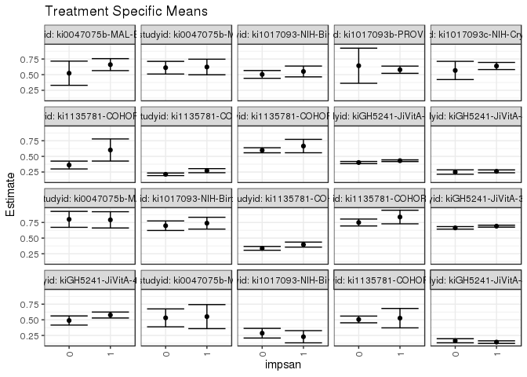

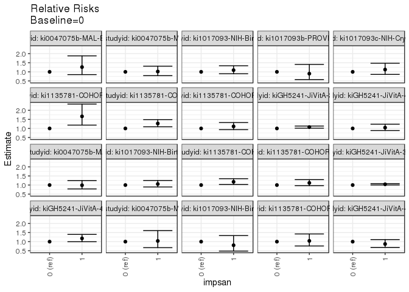

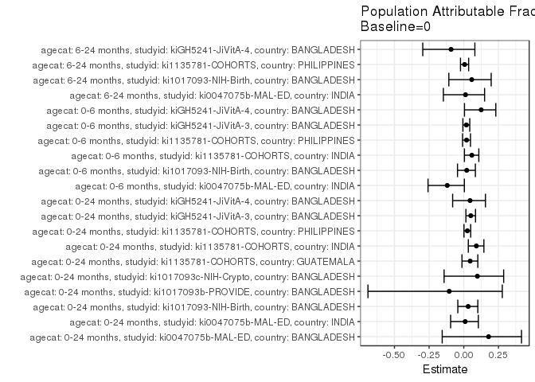

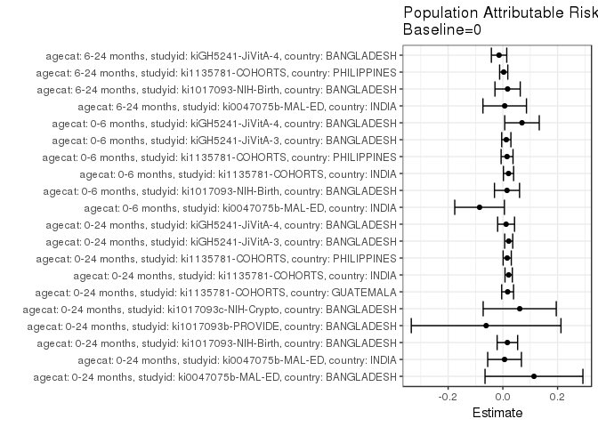

## Results Table

### Parameter: TSM

| agecat | studyid | country | intervention_level | baseline_level | estimate | ci_lower | ci_upper |
| --- | --- | --- | --- | --- | --- | --- | --- |
| 0-24 months | ki0047075b-MAL-ED | BANGLADESH | 0 | NA | 0.5226385 | 0.3292190 | 0.7160580 |
| 0-24 months | ki0047075b-MAL-ED | BANGLADESH | 1 | NA | 0.6602222 | 0.5644891 | 0.7559553 |
| 0-24 months | ki0047075b-MAL-ED | INDIA | 0 | NA | 0.6114220 | 0.5104755 | 0.7123685 |
| 0-24 months | ki0047075b-MAL-ED | INDIA | 1 | NA | 0.6226312 | 0.4982238 | 0.7470386 |
| 0-24 months | ki1017093-NIH-Birth | BANGLADESH | 0 | NA | 0.5036496 | 0.4414527 | 0.5658466 |
| 0-24 months | ki1017093-NIH-Birth | BANGLADESH | 1 | NA | 0.5510204 | 0.4645738 | 0.6374670 |
| 0-24 months | ki1017093b-PROVIDE | BANGLADESH | 0 | NA | 0.6428571 | 0.3621822 | 0.9235321 |
| 0-24 months | ki1017093b-PROVIDE | BANGLADESH | 1 | NA | 0.5787671 | 0.5206376 | 0.6368967 |
| 0-24 months | ki1017093c-NIH-Crypto | BANGLADESH | 0 | NA | 0.5670474 | 0.4213853 | 0.7127094 |
| 0-24 months | ki1017093c-NIH-Crypto | BANGLADESH | 1 | NA | 0.6383104 | 0.5813725 | 0.6952483 |
| 0-24 months | ki1135781-COHORTS | GUATEMALA | 0 | NA | 0.3613918 | 0.2987102 | 0.4240734 |
| 0-24 months | ki1135781-COHORTS | GUATEMALA | 1 | NA | 0.6016691 | 0.4249658 | 0.7783724 |
| 0-24 months | ki1135781-COHORTS | INDIA | 0 | NA | 0.2132155 | 0.1923829 | 0.2340481 |
| 0-24 months | ki1135781-COHORTS | INDIA | 1 | NA | 0.2713547 | 0.2386151 | 0.3040944 |
| 0-24 months | ki1135781-COHORTS | PHILIPPINES | 0 | NA | 0.5975448 | 0.5571743 | 0.6379153 |
| 0-24 months | ki1135781-COHORTS | PHILIPPINES | 1 | NA | 0.6648199 | 0.5576780 | 0.7719618 |
| 0-24 months | kiGH5241-JiVitA-3 | BANGLADESH | 0 | NA | 0.4014341 | 0.3840234 | 0.4188448 |
| 0-24 months | kiGH5241-JiVitA-3 | BANGLADESH | 1 | NA | 0.4307350 | 0.4173736 | 0.4440963 |
| 0-24 months | kiGH5241-JiVitA-4 | BANGLADESH | 0 | NA | 0.2494844 | 0.2142109 | 0.2847579 |
| 0-24 months | kiGH5241-JiVitA-4 | BANGLADESH | 1 | NA | 0.2607575 | 0.2380430 | 0.2834719 |
| 0-6 months | ki0047075b-MAL-ED | INDIA | 0 | NA | 0.7993941 | 0.6719347 | 0.9268536 |
| 0-6 months | ki0047075b-MAL-ED | INDIA | 1 | NA | 0.7914626 | 0.6615046 | 0.9214206 |
| 0-6 months | ki1017093-NIH-Birth | BANGLADESH | 0 | NA | 0.6978441 | 0.6217005 | 0.7739878 |
| 0-6 months | ki1017093-NIH-Birth | BANGLADESH | 1 | NA | 0.7380916 | 0.6434316 | 0.8327516 |
| 0-6 months | ki1135781-COHORTS | INDIA | 0 | NA | 0.3359027 | 0.3054813 | 0.3663240 |
| 0-6 months | ki1135781-COHORTS | INDIA | 1 | NA | 0.3957034 | 0.3556230 | 0.4357839 |
| 0-6 months | ki1135781-COHORTS | PHILIPPINES | 0 | NA | 0.7489177 | 0.6935154 | 0.8043201 |
| 0-6 months | ki1135781-COHORTS | PHILIPPINES | 1 | NA | 0.8367347 | 0.7280039 | 0.9454655 |
| 0-6 months | kiGH5241-JiVitA-3 | BANGLADESH | 0 | NA | 0.6630287 | 0.6425050 | 0.6835524 |
| 0-6 months | kiGH5241-JiVitA-3 | BANGLADESH | 1 | NA | 0.6903671 | 0.6748267 | 0.7059075 |
| 0-6 months | kiGH5241-JiVitA-4 | BANGLADESH | 0 | NA | 0.4884357 | 0.4153963 | 0.5614752 |
| 0-6 months | kiGH5241-JiVitA-4 | BANGLADESH | 1 | NA | 0.5763621 | 0.5288512 | 0.6238730 |
| 6-24 months | ki0047075b-MAL-ED | INDIA | 0 | NA | 0.5309053 | 0.3876477 | 0.6741630 |
| 6-24 months | ki0047075b-MAL-ED | INDIA | 1 | NA | 0.5510709 | 0.3589226 | 0.7432192 |
| 6-24 months | ki1017093-NIH-Birth | BANGLADESH | 0 | NA | 0.2857110 | 0.2082788 | 0.3631432 |
| 6-24 months | ki1017093-NIH-Birth | BANGLADESH | 1 | NA | 0.2290989 | 0.1314947 | 0.3267032 |
| 6-24 months | ki1135781-COHORTS | PHILIPPINES | 0 | NA | 0.5055684 | 0.4518231 | 0.5593137 |
| 6-24 months | ki1135781-COHORTS | PHILIPPINES | 1 | NA | 0.5263355 | 0.3712983 | 0.6813728 |
| 6-24 months | kiGH5241-JiVitA-4 | BANGLADESH | 0 | NA | 0.1647654 | 0.1320702 | 0.1974606 |
| 6-24 months | kiGH5241-JiVitA-4 | BANGLADESH | 1 | NA | 0.1434737 | 0.1229830 | 0.1639643 |

### Parameter: E(Y)

| agecat | studyid | country | intervention_level | baseline_level | estimate | ci_lower | ci_upper |
| --- | --- | --- | --- | --- | --- | --- | --- |
| 0-24 months | ki0047075b-MAL-ED | BANGLADESH | NA | NA | 0.6363636 | 0.5494154 | 0.7233119 |
| 0-24 months | ki0047075b-MAL-ED | INDIA | NA | NA | 0.6176471 | 0.5365376 | 0.6987565 |
| 0-24 months | ki1017093-NIH-Birth | BANGLADESH | NA | NA | 0.5201900 | 0.4695846 | 0.5707955 |
| 0-24 months | ki1017093b-PROVIDE | BANGLADESH | NA | NA | 0.5816993 | 0.5247676 | 0.6386311 |
| 0-24 months | ki1017093c-NIH-Crypto | BANGLADESH | NA | NA | 0.6286645 | 0.5746609 | 0.6826681 |
| 0-24 months | ki1135781-COHORTS | GUATEMALA | NA | NA | 0.3787879 | 0.3179432 | 0.4396325 |
| 0-24 months | ki1135781-COHORTS | INDIA | NA | NA | 0.2344546 | 0.2156201 | 0.2532892 |
| 0-24 months | ki1135781-COHORTS | PHILIPPINES | NA | NA | 0.6134700 | 0.5751620 | 0.6517779 |
| 0-24 months | kiGH5241-JiVitA-3 | BANGLADESH | NA | NA | 0.4228277 | 0.4116994 | 0.4339560 |
| 0-24 months | kiGH5241-JiVitA-4 | BANGLADESH | NA | NA | 0.2613103 | 0.2419607 | 0.2806599 |
| 0-6 months | ki0047075b-MAL-ED | INDIA | NA | NA | 0.7142857 | 0.6098683 | 0.8187031 |
| 0-6 months | ki1017093-NIH-Birth | BANGLADESH | NA | NA | 0.7130045 | 0.6535890 | 0.7724200 |
| 0-6 months | ki1135781-COHORTS | INDIA | NA | NA | 0.3565891 | 0.3304405 | 0.3827378 |
| 0-6 months | ki1135781-COHORTS | PHILIPPINES | NA | NA | 0.7642857 | 0.7146210 | 0.8139505 |
| 0-6 months | kiGH5241-JiVitA-3 | BANGLADESH | NA | NA | 0.6756128 | 0.6622741 | 0.6889516 |
| 0-6 months | kiGH5241-JiVitA-4 | BANGLADESH | NA | NA | 0.5583942 | 0.5167799 | 0.6000084 |
| 6-24 months | ki0047075b-MAL-ED | INDIA | NA | NA | 0.5376344 | 0.4216441 | 0.6536248 |
| 6-24 months | ki1017093-NIH-Birth | BANGLADESH | NA | NA | 0.3030303 | 0.2377927 | 0.3682679 |
| 6-24 months | ki1135781-COHORTS | PHILIPPINES | NA | NA | 0.5086849 | 0.4571562 | 0.5602135 |
| 6-24 months | kiGH5241-JiVitA-4 | BANGLADESH | NA | NA | 0.1508986 | 0.1332882 | 0.1685090 |

### Parameter: RR

| agecat | studyid | country | intervention_level | baseline_level | estimate | ci_lower | ci_upper |
| --- | --- | --- | --- | --- | --- | --- | --- |
| 0-24 months | ki0047075b-MAL-ED | BANGLADESH | 0 | 0 | 1.0000000 | 1.0000000 | 1.000000 |
| 0-24 months | ki0047075b-MAL-ED | BANGLADESH | 1 | 0 | 1.2632482 | 0.8489739 | 1.879676 |
| 0-24 months | ki0047075b-MAL-ED | INDIA | 0 | 0 | 1.0000000 | 1.0000000 | 1.000000 |
| 0-24 months | ki0047075b-MAL-ED | INDIA | 1 | 0 | 1.0183330 | 0.7896897 | 1.313176 |
| 0-24 months | ki1017093-NIH-Birth | BANGLADESH | 0 | 0 | 1.0000000 | 1.0000000 | 1.000000 |
| 0-24 months | ki1017093-NIH-Birth | BANGLADESH | 1 | 0 | 1.0940550 | 0.8959643 | 1.335942 |
| 0-24 months | ki1017093b-PROVIDE | BANGLADESH | 0 | 0 | 1.0000000 | 1.0000000 | 1.000000 |
| 0-24 months | ki1017093b-PROVIDE | BANGLADESH | 1 | 0 | 0.9003044 | 0.5752332 | 1.409077 |
| 0-24 months | ki1017093c-NIH-Crypto | BANGLADESH | 0 | 0 | 1.0000000 | 1.0000000 | 1.000000 |
| 0-24 months | ki1017093c-NIH-Crypto | BANGLADESH | 1 | 0 | 1.1256738 | 0.8600925 | 1.473262 |
| 0-24 months | ki1135781-COHORTS | GUATEMALA | 0 | 0 | 1.0000000 | 1.0000000 | 1.000000 |
| 0-24 months | ki1135781-COHORTS | GUATEMALA | 1 | 0 | 1.6648666 | 1.1842361 | 2.340564 |
| 0-24 months | ki1135781-COHORTS | INDIA | 0 | 0 | 1.0000000 | 1.0000000 | 1.000000 |
| 0-24 months | ki1135781-COHORTS | INDIA | 1 | 0 | 1.2726784 | 1.0902265 | 1.485664 |
| 0-24 months | ki1135781-COHORTS | PHILIPPINES | 0 | 0 | 1.0000000 | 1.0000000 | 1.000000 |
| 0-24 months | ki1135781-COHORTS | PHILIPPINES | 1 | 0 | 1.1125859 | 0.9341236 | 1.325143 |
| 0-24 months | kiGH5241-JiVitA-3 | BANGLADESH | 0 | 0 | 1.0000000 | 1.0000000 | 1.000000 |
| 0-24 months | kiGH5241-JiVitA-3 | BANGLADESH | 1 | 0 | 1.0729904 | 1.0178485 | 1.131120 |
| 0-24 months | kiGH5241-JiVitA-4 | BANGLADESH | 0 | 0 | 1.0000000 | 1.0000000 | 1.000000 |
| 0-24 months | kiGH5241-JiVitA-4 | BANGLADESH | 1 | 0 | 1.0451854 | 0.8851407 | 1.234168 |
| 0-6 months | ki0047075b-MAL-ED | INDIA | 0 | 0 | 1.0000000 | 1.0000000 | 1.000000 |
| 0-6 months | ki0047075b-MAL-ED | INDIA | 1 | 0 | 0.9900780 | 0.7858995 | 1.247303 |
| 0-6 months | ki1017093-NIH-Birth | BANGLADESH | 0 | 0 | 1.0000000 | 1.0000000 | 1.000000 |
| 0-6 months | ki1017093-NIH-Birth | BANGLADESH | 1 | 0 | 1.0576739 | 0.8937651 | 1.251642 |
| 0-6 months | ki1135781-COHORTS | INDIA | 0 | 0 | 1.0000000 | 1.0000000 | 1.000000 |
| 0-6 months | ki1135781-COHORTS | INDIA | 1 | 0 | 1.1780301 | 1.0286901 | 1.349050 |
| 0-6 months | ki1135781-COHORTS | PHILIPPINES | 0 | 0 | 1.0000000 | 1.0000000 | 1.000000 |
| 0-6 months | ki1135781-COHORTS | PHILIPPINES | 1 | 0 | 1.1172585 | 0.9620873 | 1.297457 |
| 0-6 months | kiGH5241-JiVitA-3 | BANGLADESH | 0 | 0 | 1.0000000 | 1.0000000 | 1.000000 |
| 0-6 months | kiGH5241-JiVitA-3 | BANGLADESH | 1 | 0 | 1.0412327 | 1.0026253 | 1.081327 |
| 0-6 months | kiGH5241-JiVitA-4 | BANGLADESH | 0 | 0 | 1.0000000 | 1.0000000 | 1.000000 |
| 0-6 months | kiGH5241-JiVitA-4 | BANGLADESH | 1 | 0 | 1.1800164 | 0.9952054 | 1.399147 |
| 6-24 months | ki0047075b-MAL-ED | INDIA | 0 | 0 | 1.0000000 | 1.0000000 | 1.000000 |
| 6-24 months | ki0047075b-MAL-ED | INDIA | 1 | 0 | 1.0379834 | 0.6699197 | 1.608267 |
| 6-24 months | ki1017093-NIH-Birth | BANGLADESH | 0 | 0 | 1.0000000 | 1.0000000 | 1.000000 |
| 6-24 months | ki1017093-NIH-Birth | BANGLADESH | 1 | 0 | 0.8018555 | 0.4818848 | 1.334286 |
| 6-24 months | ki1135781-COHORTS | PHILIPPINES | 0 | 0 | 1.0000000 | 1.0000000 | 1.000000 |
| 6-24 months | ki1135781-COHORTS | PHILIPPINES | 1 | 0 | 1.0410768 | 0.7612005 | 1.423857 |
| 6-24 months | kiGH5241-JiVitA-4 | BANGLADESH | 0 | 0 | 1.0000000 | 1.0000000 | 1.000000 |
| 6-24 months | kiGH5241-JiVitA-4 | BANGLADESH | 1 | 0 | 0.8707754 | 0.6818459 | 1.112054 |

### Parameter: PAR

| agecat | studyid | country | intervention_level | baseline_level | estimate | ci_lower | ci_upper |
| --- | --- | --- | --- | --- | --- | --- | --- |
| 0-24 months | ki0047075b-MAL-ED | BANGLADESH | 0 | NA | 0.1137251 | -0.0651501 | 0.2926003 |
| 0-24 months | ki0047075b-MAL-ED | INDIA | 0 | NA | 0.0062251 | -0.0553822 | 0.0678323 |
| 0-24 months | ki1017093-NIH-Birth | BANGLADESH | 0 | NA | 0.0165404 | -0.0209030 | 0.0539838 |
| 0-24 months | ki1017093b-PROVIDE | BANGLADESH | 0 | NA | -0.0611578 | -0.3347113 | 0.2123957 |
| 0-24 months | ki1017093c-NIH-Crypto | BANGLADESH | 0 | NA | 0.0616171 | -0.0719597 | 0.1951939 |
| 0-24 months | ki1135781-COHORTS | GUATEMALA | 0 | NA | 0.0173961 | -0.0042925 | 0.0390847 |
| 0-24 months | ki1135781-COHORTS | INDIA | 0 | NA | 0.0212392 | 0.0078514 | 0.0346270 |
| 0-24 months | ki1135781-COHORTS | PHILIPPINES | 0 | NA | 0.0159252 | 0.0010257 | 0.0308247 |
| 0-24 months | kiGH5241-JiVitA-3 | BANGLADESH | 0 | NA | 0.0213935 | 0.0066668 | 0.0361203 |
| 0-24 months | kiGH5241-JiVitA-4 | BANGLADESH | 0 | NA | 0.0118259 | -0.0190489 | 0.0427006 |
| 0-6 months | ki0047075b-MAL-ED | INDIA | 0 | NA | -0.0851084 | -0.1758471 | 0.0056303 |
| 0-6 months | ki1017093-NIH-Birth | BANGLADESH | 0 | NA | 0.0151603 | -0.0306757 | 0.0609963 |
| 0-6 months | ki1135781-COHORTS | INDIA | 0 | NA | 0.0206865 | 0.0020858 | 0.0392872 |
| 0-6 months | ki1135781-COHORTS | PHILIPPINES | 0 | NA | 0.0153680 | -0.0063811 | 0.0371170 |
| 0-6 months | kiGH5241-JiVitA-3 | BANGLADESH | 0 | NA | 0.0125842 | -0.0042187 | 0.0293870 |
| 0-6 months | kiGH5241-JiVitA-4 | BANGLADESH | 0 | NA | 0.0699584 | 0.0068874 | 0.1330295 |
| 6-24 months | ki0047075b-MAL-ED | INDIA | 0 | NA | 0.0067291 | -0.0728133 | 0.0862714 |
| 6-24 months | ki1017093-NIH-Birth | BANGLADESH | 0 | NA | 0.0173193 | -0.0288678 | 0.0635064 |
| 6-24 months | ki1135781-COHORTS | PHILIPPINES | 0 | NA | 0.0031165 | -0.0118033 | 0.0180362 |
| 6-24 months | kiGH5241-JiVitA-4 | BANGLADESH | 0 | NA | -0.0138668 | -0.0419791 | 0.0142455 |

### Parameter: PAF

| agecat | studyid | country | intervention_level | baseline_level | estimate | ci_lower | ci_upper |
| --- | --- | --- | --- | --- | --- | --- | --- |
| 0-24 months | ki0047075b-MAL-ED | BANGLADESH | 0 | NA | 0.1787109 | -0.1555936 | 0.4163036 |
| 0-24 months | ki0047075b-MAL-ED | INDIA | 0 | NA | 0.0100787 | -0.0948475 | 0.1049491 |
| 0-24 months | ki1017093-NIH-Birth | BANGLADESH | 0 | NA | 0.0317968 | -0.0429151 | 0.1011566 |
| 0-24 months | ki1017093b-PROVIDE | BANGLADESH | 0 | NA | -0.1051364 | -0.6911138 | 0.2777975 |
| 0-24 months | ki1017093c-NIH-Crypto | BANGLADESH | 0 | NA | 0.0980127 | -0.1421262 | 0.2876610 |
| 0-24 months | ki1135781-COHORTS | GUATEMALA | 0 | NA | 0.0459256 | -0.0128669 | 0.1013056 |
| 0-24 months | ki1135781-COHORTS | INDIA | 0 | NA | 0.0905896 | 0.0327079 | 0.1450078 |
| 0-24 months | ki1135781-COHORTS | PHILIPPINES | 0 | NA | 0.0259592 | 0.0013982 | 0.0499161 |
| 0-24 months | kiGH5241-JiVitA-3 | BANGLADESH | 0 | NA | 0.0505964 | 0.0152527 | 0.0846715 |
| 0-24 months | kiGH5241-JiVitA-4 | BANGLADESH | 0 | NA | 0.0452560 | -0.0803086 | 0.1562262 |
| 0-6 months | ki0047075b-MAL-ED | INDIA | 0 | NA | -0.1191518 | -0.2579343 | 0.0043195 |
| 0-6 months | ki1017093-NIH-Birth | BANGLADESH | 0 | NA | 0.0212626 | -0.0452652 | 0.0835562 |
| 0-6 months | ki1135781-COHORTS | INDIA | 0 | NA | 0.0580121 | 0.0046775 | 0.1084888 |
| 0-6 months | ki1135781-COHORTS | PHILIPPINES | 0 | NA | 0.0201076 | -0.0088778 | 0.0482603 |
| 0-6 months | kiGH5241-JiVitA-3 | BANGLADESH | 0 | NA | 0.0186263 | -0.0065320 | 0.0431557 |
| 0-6 months | kiGH5241-JiVitA-4 | BANGLADESH | 0 | NA | 0.1252851 | 0.0050375 | 0.2309999 |
| 6-24 months | ki0047075b-MAL-ED | INDIA | 0 | NA | 0.0125161 | -0.1472454 | 0.1500297 |
| 6-24 months | ki1017093-NIH-Birth | BANGLADESH | 0 | NA | 0.0571537 | -0.1079142 | 0.1976282 |
| 6-24 months | ki1135781-COHORTS | PHILIPPINES | 0 | NA | 0.0061265 | -0.0236518 | 0.0350386 |
| 6-24 months | kiGH5241-JiVitA-4 | BANGLADESH | 0 | NA | -0.0918947 | -0.2957999 | 0.0799242 |